# Chapter 2 Solutions

1.*A test is graded from 0 to 50, with an average score of 35 and a standard deviation of 10. For comparison to other tests, it would be convenient to rescale to a mean of 100 and standard deviation of 15.*

*(a) How can the scores be linearly transformed to have this new mean and standard deviation?*

Lets define our random variable,

$X$ : a test graded from 0 to 50 $\mu_X = 35 ,\sigma_X = 10$

To have this new mean and std lets define a r.v called Y

$Y=a*X+b$ we know from the question our new variable has $\mu_Y = 100 ,\sigma_Y = 15$

Lets find a and b,

$$E[Y] = a*E[X] + b \\
100 = a*35 + b \\
V[Y] = a^2*V[X] \\
\sqrt{V[Y]} = \sqrt{a^2V[X]}\\
15 = 10*a ; \ a = 1.5 \\
100 = 1.5*35 + b; \ b = 47.5$$

And plugging results we get $Y = 1.5*X+47.5$

*(b) There is another linear transformation that also rescales the scores to have mean 100 and standard deviation 15. What is it, and why would you not want to use it for this purpose?*

When we calculated term a we took root of $a^2$ since a can be $\pm1.5$ we can take $a$ as -1.5. Thus we get
$$a = -1.5; \ b= 100 + 1.5*35 = 152.5 \\Y = -1.5*X+ 152.5$$
We don’t want that equation. Lets take X as 0 and 50 plugging these values to transformation of Y we have 152.5 and 77.5 which is not a desirable transformation.

2.*The following are the proportions of girl births in Vienna for each month in 1908 and 1909 (out of an average of 3900 births per month):*

```r
girls <- c(.4777, .4875, .4859, .4754, .4874, .4864, .4813, .4787, .4895, .4797, .4876, .4859,.4857, .4907, .5010, .4903, .4860, .4911, .4871, .4725, .4822, .4870, .4823, .4973)
```

a)*Compute the standard deviation of these proportions and compare to the standard deviation that would be expected if the sexes of babies were inde- pendently decided with a constant probability over the 24-month period.*

```r
print(std.obs)
```

```
[1] 0.006409724
```

```r
p.obs <- mean(girls)
std.expected <- sqrt(p.obs*(1-p.obs)/3900)
print(std.expected)
```

```
[1] 0.008003121
```

We got expected sd 0.008 which different from observed sd.

b)*The actual and theoretical standard deviations from (a) differ, of course. Is this difference statistically significant? (Hint: under the randomness model, the actual variance should have a distribution with expected value equal to the theoretical variance, and proportional to a $\chi^2$ with 23 degrees of freedom.)*

```r
upper <- qchisq(.025,23)
lower <- qchisq(.975,23)
uplimit <- sqrt(23*std.obs^2 / upper)
lwlimit <- sqrt(23*std.obs^2 / lower)
print(paste(lwlimit,"<sigma<",uplimit))
```

```
[1] "0.00498172479779268 <sigma< 0.00899130873876103"
```

We can see our observed value of std is in the confidence interval.We can say the observed std is not significantly different from expected std.

3.*Demonstration of the Central Limit Theorem: let x = x1 + · · · + x20, the sum of 20 independent Uniform(0,1) random variables. In R, create 1000 simulations of x and plot their histogram. On the histogram, overlay a graph of the normal density function. Comment on any differences between the histogram and the curve.*

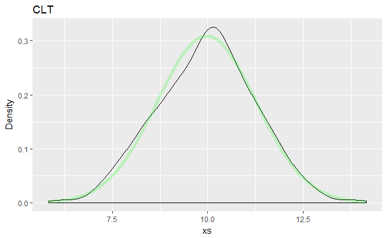

CLT WORKS!

4.*Distribution of averages and differences: the heights of men in the United States are approximately normally distributed with mean 69.1 inches and standard deviation 2.9 inches. The heights of women are approximately normally distributed with mean 63.7 inches and standard deviation 2.7 inches. Let x be the average height of 100 randomly sampled men, and y be the average height of 100 randomly sampled women. In R, create 1000 simulations of x - y and plot their histogram. Using the simulations, compute the mean and standard deviation of the distribution of x - y and compare to their exact values.*

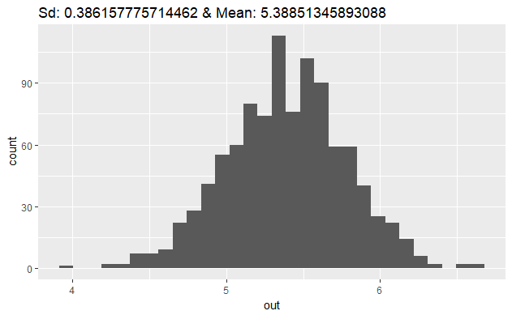

```r
men.mean <- 69.1
men.std <- 2.8
women.mean <- 63.7
women.std <-2.7
n = 100
X <- rnorm(n=n,mean=men.mean,sd=men.std)
Y <- rnorm(n=n,mean=women.mean,sd=women.std)
sim.out = replicate(1000,mean(rnorm(n=n,mean=men.mean,sd=men.std))-mean(rnorm(n=n,mean=women.mean,sd=women.std)))
sim.out <- data.frame(out=sim.out)
ggplot(sim.out,aes(x=out)) + geom_histogram() + ggtitle(paste("Sd:",sd(sim.out$out),"& Mean:",mean(sim.out$out)))
```

```r
print(paste("Sd:",sd(sim.out$out),"& Mean:",mean(sim.out$out)))
```

```
[1] "Sd: 0.386157775714462 & Mean: 5.38851345893088"
```

5.*Correlated random variables: suppose that the heights of husbands and wives have a correlation of 0.3. Let x and y be the heights of a married couple chosen at random. What are the mean and standard deviation of the average height, (x + y)/2?*

```r
rho <- .3
mu_exp <- (men.mean + women.mean) / 2
sd_exp <- sqrt(men.std^2+women.std^2+2*rho*men.std^2*women.std^2)/2
print(paste("Mu: ",mu_exp,"& SD: ",sd_exp))
```

```
[1] "Mu:  66.4 & SD:  3.51504480768027"
```

Proof:
$${COV(X,Y) \over{\sqrt{V(X)V(Y)}}} = .3 \\
COV(X,Y) = 0.3*\sqrt{V(X)V(Y)} \\
V({X+Y\over{2}}) = {1\over{4}}(V(X)+V(Y)+2*COV(X,Y))$$